# 06 - Simple Statistical Tests Answers

# Introduction and Setup

For these exercises, we will look at the core concepts from this lesson.

For these exercises we’ll use simulated data sets from the **inputs** folder. This data was saved as a .csv, so we need to use `read_csv()` to load the data into R.

```r
library(tidyverse)
```

Next, we’ll load all of the data sets.

```r
binom_b_data <- read_csv("inputs/binom_between_data.csv")
binom_w_data <- read_csv("inputs/binom_within_data.csv")
bsubj_data <- read_csv("inputs/bsubj_data.csv")
wsubj_data <- read_csv("inputs/wsubj_data.csv")
corr_data <- read_csv("inputs/corr_data.csv")
```

## Question 1

Using the `corr_data` data set, prepare to run a correlation for the height and weights of the participants. First, you have to check all of the assumptions are met for a parametric test. Do a visual inspection of the normality of the variables, and check that the two are linearly related.

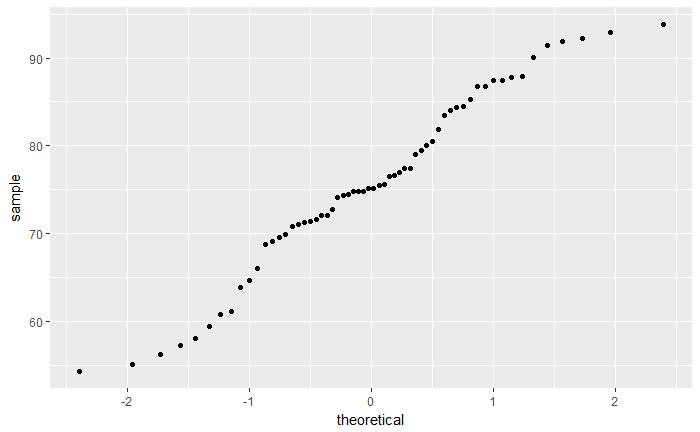

```r
corr_data %>%
  ggplot(aes(sample = weight)) +
    geom_qq()
```

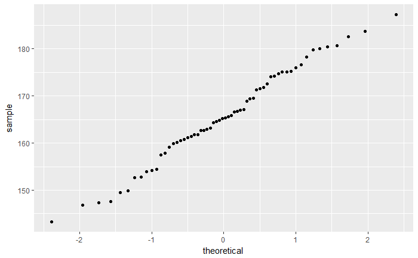

```r
corr_data %>%
  ggplot(aes(sample = height)) +
    geom_qq()
```

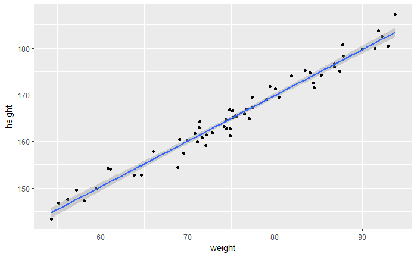

```r
# plot one
corr_data %>%
  ggplot(aes(x = weight, y = height)) +
    geom_point() +
    geom_smooth(method = "lm")
```

## Question 2

Using the information from Question 1, run a correlation for the height and weights of the participants. Adjust to a non-parametric test if necessary.

```r
cor.test(corr_data$weight, corr_data$height
         )
```

```
    Pearson's product-moment correlation

data:  corr_data$weight and corr_data$height
t = 41.708, df = 58, p-value < 2.2e-16
alternative hypothesis: true correlation is not equal to 0
95 percent confidence interval:
 0.9728130 0.9902901
sample estimates:
      cor
0.9837344
```

What is the correlation between the two variables? Can you work out the $R^2$? What does this tell us?

*Answer*: The correlation coefficient is 0.98, with the $R^2$ = 0.9604. This tells us that 0.9604 of the variance in height is explained by weight.

## Question 3

Aggregate the scores of the `bsubj_data` data set by subject as an object called `bsubj_agg`. Output the mean scores aggregated by subject.

Then run a *t*-test between the two groups of A. Is there a significant difference between the two conditions?

```r
bsubj_agg <- bsubj_data %>%
  group_by(subj_id, A) %>%
  summarise(Y = mean(Y))
bsubj_agg
```

| subj_id | A | Y |
| --- | --- | --- |
| 1 | A2 | 378.9836 |
| 2 | A1 | 277.4088 |
| 3 | A1 | 273.6713 |
| 4 | A1 | 268.8980 |
| 5 | A1 | 273.8441 |
| 6 | A2 | 381.7657 |
| 7 | A1 | 272.6388 |
| 8 | A2 | 367.2244 |
| 9 | A2 | 381.3870 |
| 10 | A1 | 279.6259 |

[output cut: 50 more lines]

```r
t.test(Y ~ A, data = bsubj_agg, paired = FALSE)
```

```
    Welch Two Sample t-test

data:  Y by A
t = -57.145, df = 53.917, p-value < 2.2e-16
alternative hypothesis: true difference in means is not equal to 0
95 percent confidence interval:
 -110.5217 -103.0292
sample estimates:
mean in group A1 mean in group A2
        271.1893         377.9647
```

**Answer**: Yes, there is a significant difference between the two conditions at the 0.05 alpha threshold (*p* < .05).

## Question 4

Check that a *t*-test was appropriate for question 3. We’ll only check for **homogeneity of variance** here. What did the test show? Was a *t*-test appropriate?

```r
bartlett.test(Y ~ A, data = bsubj_agg)
```

```
    Bartlett test of homogeneity of variances

data:  Y by A
Bartlett's K-squared = 2.2451, df = 1, p-value = 0.134
```

**Answer**: The test was non-signfiicant, indicating homogeneity of variance. Thus, the *t*-test was appropriate.

## Question 5

Aggregate the `wsubj_data` by subjects and save this as the object `wsubj_agg`. Then submit this aggregated data to an ANOVA, saving the output as the object `wsubj_aov`. What does the ANOVA show us?

```r
wsubj_agg <- wsubj_data %>%
  group_by(subj_id, A) %>%
  summarise(Y = mean(Y))
wsubj_aov <- aov(Y ~ A + Error(subj_id/A), data = wsubj_agg)
summary(wsubj_aov)
```

```
Error: subj_id
          Df Sum Sq Mean Sq F value Pr(>F)
Residuals  1  35.62   35.62

Error: subj_id:A
  Df Sum Sq Mean Sq
A  1 250328  250328

Error: Within
           Df Sum Sq Mean Sq F value Pr(>F)
A           1  79577   79577    1484 <2e-16 ***
Residuals 116   6221      54
---
Signif. codes:  0 *** 0.001 ** 0.01 * 0.05 . 0.1   1
```

**Answer**: The paired samples ANOVA showed a significant difference between the two conditions.

## Question 6

We should probably allow people to interpret our inferential tests with plots and descriptive statistics.

First, make a plot of the two conditions from Question 5, using your `wsubj_agg` data set. Then, output a table of means, standard deviations, and standard errors for the two groups. To calculate the standard error you need to take the standard deviation of the dependent variable divided by the square root of number of observations for the dependent variable (i.e. `sd(output)/sqrt(length(output))`).

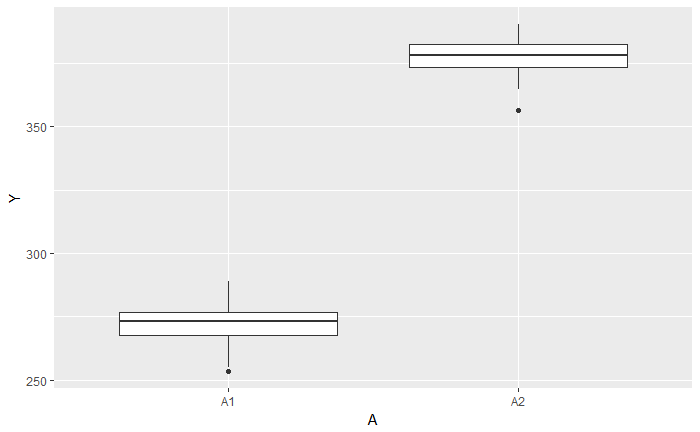

```r
ggplot(data = wsubj_agg, mapping = aes(x = A, y = Y)) +
  geom_boxplot()
```

```r
wsubj_agg %>%
  group_by(A) %>%
  summarise(mean = mean(Y),
            sd = sd(Y),
            se = sd(Y)/sqrt(length(Y))
            )
```

| A | mean | sd | se |
| --- | --- | --- | --- |
| A1 | 272.3842 | 7.381332 | 0.9529258 |
| A2 | 377.2495 | 7.184680 | 0.9275382 |

## Question 7

Fit a linear model to the `wsubj_agg` data and save this as `wsubj_lm`. How does this compare to the ANOVA from question 5? Compare the results of the parameter estimates from the linear model to that of your plot. How do these parameters compare?

```r
wsubj_lm <- lm(Y ~ A, data = wsubj_agg)
summary(wsubj_lm)
```

```
Call:
lm(formula = Y ~ A, data = wsubj_agg)

Residuals:
    Min      1Q  Median      3Q     Max
-21.066  -4.065   0.657   4.849  16.405

Coefficients:
            Estimate Std. Error t value Pr(>|t|)
(Intercept) 272.3842     0.9403  289.67   <2e-16 ***
AA2         104.8653     1.3298   78.86   <2e-16 ***
---
Signif. codes:  0 *** 0.001 ** 0.01 * 0.05 . 0.1   1

Residual standard error: 7.284 on 118 degrees of freedom
Multiple R-squared:  0.9814,    Adjusted R-squared:  0.9812
F-statistic:  6218 on 1 and 118 DF,  p-value: < 2.2e-16
```

**Answer**: The inferences made from the ANOVA and linear model are the same. As for the parameter estimates, these map onto the mean scores displayed in the plots in Question 6.